# Analysis of Nobel Prize Data

Neil Saunders

compiled 2016-10-13 22:15:53

# 1 Introduction

This document illustrates some ways to analyse data from the Nobel Prize API using the R programming language.

# 2 Getting the data

We use the [Nobel Prize API](https://nobelprize.readme.io/) to fetch laureate data in JSON format.

```r
library(ggplot2)
library(jsonlite)
library(plyr)
library(dplyr)
library(networkD3)
library(xtable)
setwd("~/Dropbox/projects/code/R")
```

```r
u <- "http://api.nobelprize.org/v1/laureate.json"
nobel <- fromJSON(u)

names(nobel)
```

```
## [1] "laureates"
```

```r
names(nobel$laureates)
```

```
##  [1] "id"              "firstname"       "surname"
##  [4] "born"            "died"            "bornCountry"
##  [7] "bornCountryCode" "bornCity"        "diedCountry"
## [10] "diedCountryCode" "diedCity"        "gender"
## [13] "prizes"
```

```r
names(nobel$laureates$prizes[[1]])
```

```
## [1] "year"         "category"     "share"        "motivation"
## [5] "affiliations"
```

The variable *nobel* is a list with one named element, *laureates*. The variable *laureates* is a data frame with 13 columns, one row per laureate. The last column, *prizes* is a list of data frames.

Note that analyses that use *prizes* may count some laureates twice. However, there are only four such individuals, which makes little difference to these charts.

# 3 Analysis

## 3.1 Multiple prize winners

We can retrieve those laureates who won more than one prize by selecting records where *nobel$laureates$prizes* has more than one row.

```r
multi <- which(sapply(nobel$laureates$prizes, function(x) nrow(x)) > 1)
winners <- nobel$laureates[multi, c("firstname", "surname", "born", "bornCountry")]
print(xtable(winners), type = "html", comment = FALSE, include.rownames = FALSE)
```

| firstname | surname | born | bornCountry |
| --- | --- | --- | --- |
| Marie | Curie, née Sklodowska | 1867-11-07 | Russian Empire (now Poland) |
| John | Bardeen | 1908-05-23 | USA |
| Linus Carl | Pauling | 1901-02-28 | USA |
| Frederick | Sanger | 1918-08-13 | United Kingdom |
| Comité international de la Croix Rouge (International Committee of the Red Cross) |  | 0000-00-00 |  |
| Office of the United Nations High Commissioner for Refugees (UNHCR) |  | 0000-00-00 |  |

Four individuals have won two prizes: Marie Curie (physics, chemistry); John Bardeen (physics); Linus Pauling (chemistry, peace); Frederick Sanger (chemistry).

## 3.2 Gender

Counting up prizes by gender reveals the huge gender gap in Nobel laureates.

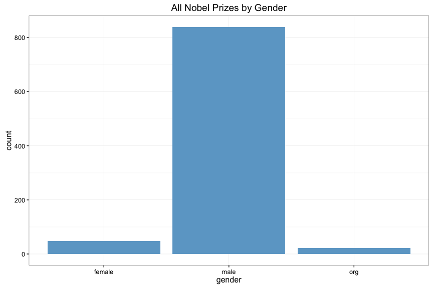

```r
gender <- as.data.frame(table(nobel$laureates$gender), stringsAsFactors = FALSE)
ggplot(gender) + geom_bar(aes(Var1, Freq), stat = "identity", fill = "skyblue3") +
    theme_bw() + labs(x = "gender", y = "count", title = "All Nobel Prizes by Gender")
```

### 3.2.1 Gender by category

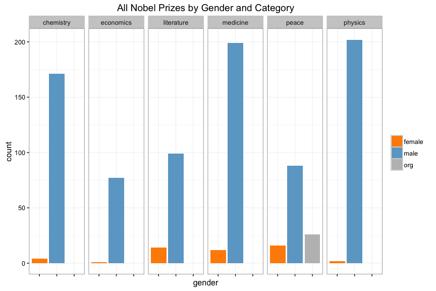

```r
cnt <- sapply(nobel$laureates$prizes, function(x) nrow(x))
prizes <- ldply(nobel$laureates$prizes, as.data.frame)
prizes$id <- rep(nobel$laureates$id, cnt)
prizes$gender <- rep(nobel$laureates$gender, cnt)
pg <- as.data.frame(table(prizes$category, prizes$gender), stringsAsFactors = FALSE)
ggplot(pg, aes(Var2, Freq)) + geom_bar(aes(fill = Var2), stat = "identity") +
    theme_bw() + facet_grid(. ~ Var1) + labs(x = "gender", y = "count", title = "All Nobel Prizes by Gender and Category") +
    scale_fill_manual(values = c("darkorange", "skyblue3", "grey"), name = NULL) +
    theme(axis.text.x = element_blank())
```

### 3.2.2 Gender over time

Is there any indication of an increase in female laureates over time?

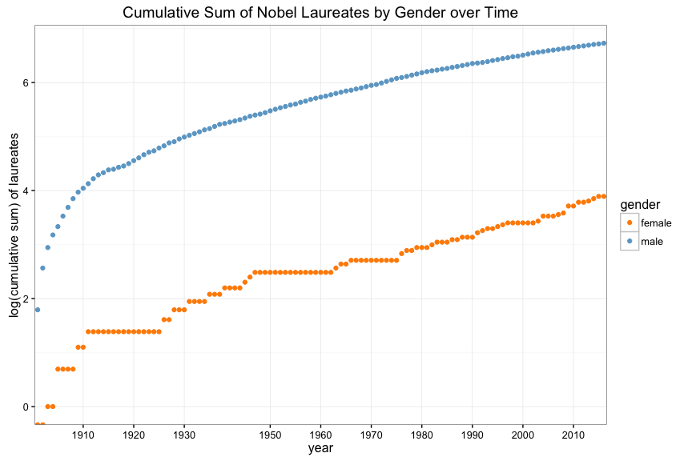

```r
p5 <- as.data.frame(table(prizes$year, prizes$gender), stringsAsFactors = FALSE)
colnames(p5) <- c("year", "gender", "Freq")
p5.1 <- mutate(group_by(p5, gender), cumsum = cumsum(Freq))
ggplot(subset(p5.1, gender != "org")) + geom_point(aes(year, log(cumsum), color = gender)) +
    theme_bw() + scale_x_discrete(breaks = seq(1900, 2015, 10)) + scale_color_manual(values = c("darkorange",
    "skyblue3")) + labs(x = "year", y = "log(cumulative sum) of laureates",
    title = "Cumulative Sum of Nobel Laureates by Gender over Time")
```

There is some indication that since about 1975, more women have won prizes than in the preceding years. What if we subset by category?

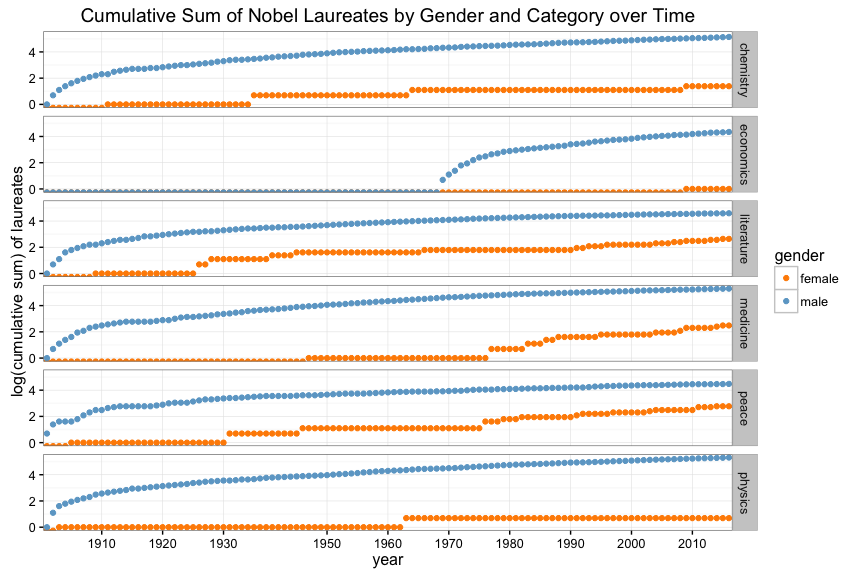

```r
p6 <- as.data.frame(table(prizes$year, prizes$category, prizes$gender), stringsAsFactors = FALSE)
colnames(p6) <- c("year", "category", "gender", "Freq")
p6.1 <- mutate(group_by(p6, category, gender), cumsum = cumsum(Freq))
ggplot(subset(p6.1, gender != "org")) + geom_point(aes(year, log(cumsum), color = gender)) +
    facet_grid(category ~ .) + theme_bw() + scale_x_discrete(breaks = seq(1900,
    2015, 10)) + scale_color_manual(values = c("darkorange", "skyblue3")) +
    labs(x = "year", y = "log(cumulative sum) of laureates", title = "Cumulative Sum of Nobel Laureates by Gender and Category over Time")
```

There is some indication that since about 1975, more women have won prizes in medicine and peace than in the preceding years. The rate of awards to women for literature also rises after about 1990.

To date, only one woman has won the prize for economics, two women have won for physics and four have won for chemistry.

## 3.3 Share

Prizes may be shared by no more than three people. How often has this occurred?

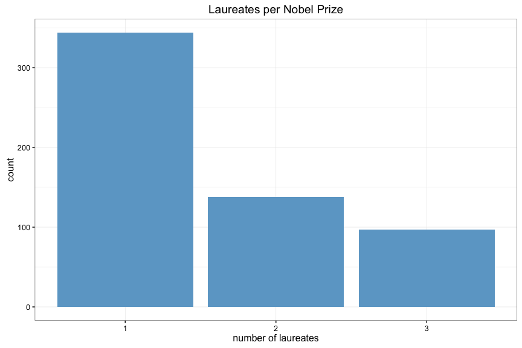

```r
share <- as.data.frame(table(prizes$year, prizes$category), stringsAsFactors = FALSE)
colnames(share) <- c("year", "category", "Freq")
share1 <- as.data.frame(table(share$Freq), stringsAsFactors = FALSE)
ggplot(share1[share1$Var1 != 0, ]) + geom_bar(aes(Var1, Freq), stat = "identity",
    fill = "skyblue3") + theme_bw() + labs(x = "number of laureates", y = "count",
    title = "Laureates per Nobel Prize")
```

Individual winners are most common.

### 3.3.1 Share by category

Are there any notable differences in prize sharing between fields?

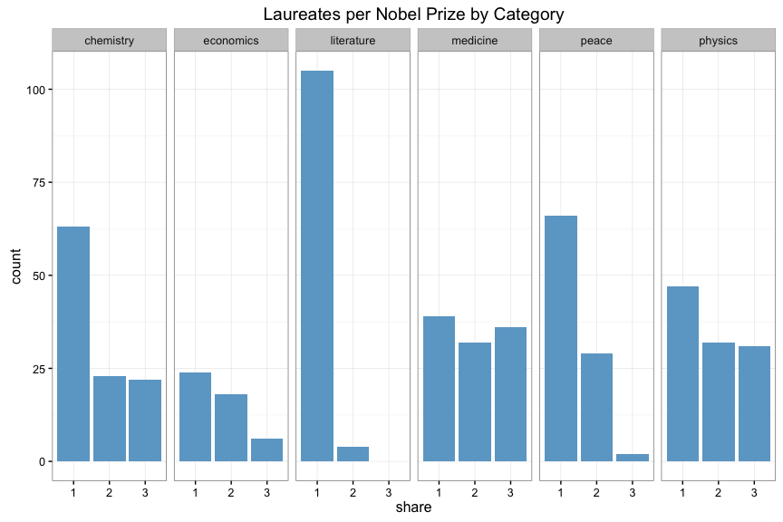

```r
share2 <- as.data.frame(table(share$category, share$Freq), stringsAsFactors = FALSE)
colnames(share2) <- c("category", "share", "Freq")
ggplot(subset(share2, share > 0)) + geom_bar(aes(share, Freq), stat = "identity",
    fill = "skyblue3") + theme_bw() + facet_grid(. ~ category) + labs(x = "share",
    y = "count", title = "Laureates per Nobel Prize by Category")
```

Individual winners are more common in all categories, notably literature and peace. In the sciences, two or three winners are roughly equally common; chemistry stands out with more individual winners than medicine or physics.

## 3.4 Ages

How old are the laureates? The data does not include the date that prizes were awarded so for those cases where birth date is available, we calculate age at the end of the year in which laureates won their prize. Median age is indicated by a point in this plot.

### 3.4.1 Ages by category

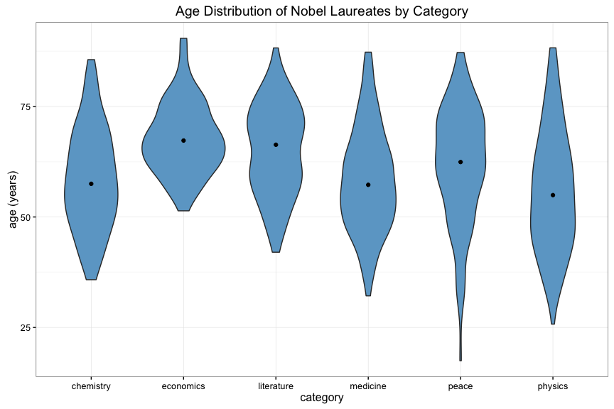

```r
prizes$born <- rep(nobel$laureates$born, cnt)
prizes$age <- as.Date(paste(prizes$year, "12-31", sep = "-"), "%Y-%m-%d") - as.Date(prizes$born, "%Y-%m-%d")
ggplot(prizes[!is.na(prizes$category), ]) + geom_violin(aes(category, as.numeric(age) / 365), fill = "skyblue3") + theme_bw() + stat_summary(aes(category, as.numeric(age) / 365), fun.y = "median", geom = "point") + labs(x = "category", y = "age (years)", title = "Age Distribution of Nobel Laureates by Category")
```

Median age is over 50 for all categories; physics laureates have the youngest median and economics the oldest. The peace prize is skewed by a recent very young “outlier”.

### 3.4.2 Ages by year awarded

Is there a change in age at which prizes were awarded over time?

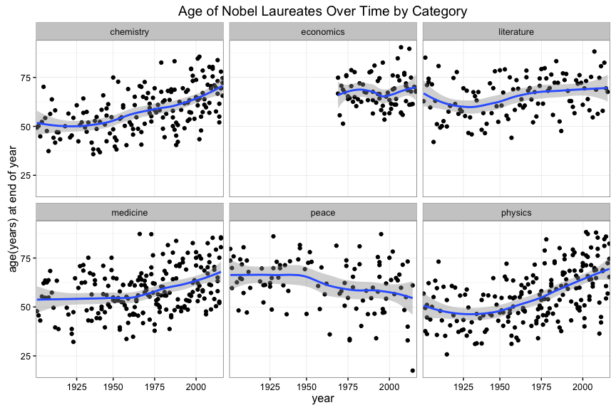

```r
ggplot(prizes[!is.na(prizes$category), ]) + geom_point(aes(year, as.numeric(age)/365)) +
    theme_bw() + geom_smooth(aes(year, as.numeric(age)/365, group = 1)) + facet_wrap(~category) +
    scale_x_discrete(breaks = seq(1900, 2015, 25)) + labs(x = "year", y = "age(years) at end of year",
    title = "Age of Nobel Laureates Over Time by Category")
```

There is a downward trend in age for the peace prize, again somewhat skewed by a young outlier. All other categories show an upward trend in age. This is especially pronounced for physics and chemistry, where laureates were much younger in the early part of the 20th century.

## 3.5 Countries

### 3.5.1 Countries by category

It is possible to calculate the number of prizes awarded by country of birth, but do the absolute numbers really tell us anything? Clearly there should be some kind of correction as larger, wealthier countries might be expected to produce more laureates. However, this is not straightforward - what correction should be applied? Using current population, for example, might generate a bias towards very small countries with only one or two laureates. In addition, the characteristics of countries (population, GDP, borders) change over time.

We will therefore simply present the absolute numbers and let readers draw their own conclusions regarding the “success” of individual countries. This chart uses [ISO 3166 2-letter country codes](https://en.wikipedia.org/wiki/ISO_3166-1_alpha-2).

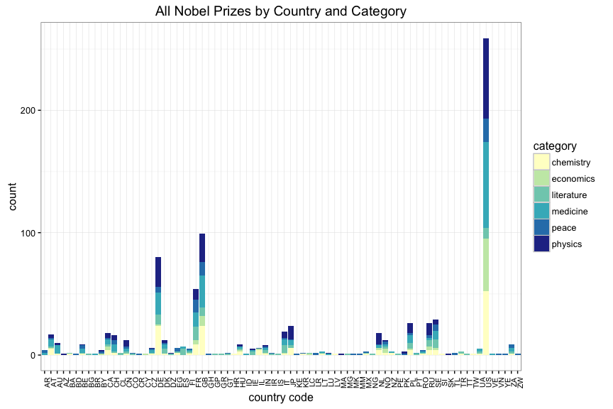

```r
# data(iso3166)
prizes$country <- rep(nobel$laureates$bornCountryCode, cnt)
p3 <- as.data.frame(table(prizes$category, prizes$country), stringsAsFactors = FALSE)
ggplot(p3) + geom_bar(aes(Var2, Freq, fill = Var1), stat = "identity", position = "stack") +
    theme_bw() + theme(axis.text.x = element_text(angle = 90, size = rel(0.82))) +
    labs(x = "country code", y = "count", title = "All Nobel Prizes by Country and Category") +
    scale_fill_manual(values = c("#ffffcc", "#c7e9b4", "#7fcdbb", "#41b6c4",
        "#2c7fb8", "#253494"), name = "category")
```

### 3.5.2 Country of birth and death

We can select records where laureates died in a different country to that of their birth and try to visualize migration. This code generates a Sankey diagram using the D3 library.

```r
country <- as.data.frame(table(nobel$laureates$bornCountryCode, nobel$laureates$diedCountryCode),
    stringsAsFactors = FALSE)
c1 <- subset(country, Freq > 0 & Var1 != Var2)
c2 <- data.frame(nodes = unique(c(nobel$laureates$bornCountryCode, nobel$laureates$diedCountryCode)))
c2 <- na.omit(c2)

m1 <- match(c1$Var1, c2$nodes)
m2 <- match(c1$Var2, c2$nodes)
c1$Var1 <- m1 - 1
c1$Var2 <- m2 - 1
sn <- sankeyNetwork(Links = c1, Nodes = c2, Source = "Var1", Target = "Var2",
    Value = "Freq", fontSize = 12, nodeWidth = 30)
```

Here is the result (interactive: try hovering over it).

[interactive chart not shown]

The migration of many laureates to the US is apparent, as is the number of laureates originating from or moving to European nations such as the UK, France, Germany and Poland.